# Problem Set 08

Your Name Here: Group X

Last updated: 2023-03-16

```r
# FIXME
library(tidyverse)
library(readxl)
library(cowplot)

theme_set(theme_cowplot())
```

## Variation Within and Between Groups

In this activity, we will explore the relationship between variances and the *F*-value using simulation and learn a new programming skill, `apply()`, as well as some `apply` relatives in the `tidyverse` that take some of the difficulty from apply functions across R structures.

Let’s start with `apply()`. `apply()` is part of a family of base R functions that all “apply”[^1] some function to sets of your data. These sets can be each row, each column, or the elements in a list (in the list case, the function is `lapply()`). `apply()` takes three arguments: the `data.frame`/`tibble` or `matrix`, the margin to apply over (1 = rows, 2 = columns), and the function to apply to each margin. You can use built in functions, a custom written one, or one you write within the apply call (these are called “anonymous” functions). We’ll show you the syntax here. Run the following and make sure you understand what is happening.

```r
ap_test <- tibble(x1 = seq(1, 10),
                  x2 = rep(5, 10),
                  x3 = seq(20, 65, length.out = 10))

# Built in R functions
(max_ap_row <- apply(ap_test, MARGIN = 1, max))
```

```
##  [1] 20 25 30 35 40 45 50 55 60 65
```

```r
(max_ap_col <- apply(ap_test, MARGIN = 2, max))
```

```
## x1 x2 x3
## 10  5 65
```

```r
(mean_ap_row <- apply(ap_test, MARGIN = 1, mean)) # == rowMeans()
```

```
##  [1]  8.666667 10.666667 12.666667 14.666667 16.666667 18.666667 20.666667
##  [8] 22.666667 24.666667 26.666667
```

```r
(mean_ap_col <- apply(ap_test, MARGIN = 2, mean)) # == colMeans()
```

```
##   x1   x2   x3
##  5.5  5.0 42.5
```

```r
# Anonymous function in the apply().
(ss <- apply(ap_test, MARGIN = 1, function(x) (x[1] * x[2]) / x[3]))
```

```
##  [1] 0.2500000 0.4000000 0.5000000 0.5714286 0.6250000 0.6666667 0.7000000
##  [8] 0.7272727 0.7500000 0.7692308
```

`pmap()` (for “parallel” `map`) passes the entire row of a `data.frame` to a function. By default, it returns a list. However, `pmap_dbl()` expects a numeric vector to be returned from the function. `pmap()` is very flexible and is the way to proceed if your functions returns a `data.frame` (with a subsequent call to `list_rbind()`).

We will use our example `ap_test` from above.

```r
# Convert anonymous function into a standalone function
myfun <- function(x1, x2, x3) (x1 * x2) / x3

pmap_dbl(ap_test, myfun) # Note that this is the same as above
```

```
##  [1] 0.2500000 0.4000000 0.5000000 0.5714286 0.6250000 0.6666667 0.7000000
##  [8] 0.7272727 0.7500000 0.7692308
```

One nice thing about `pmap` is that it will figure out the correct order for passing variables to the function. If we reorder the columns, they are still correctly interpreted by the function. Doing the same would give the wrong answer for `apply()`.

```r
ap_test_reorder <- ap_test[, c(3, 2, 1)]
pmap_dbl(ap_test_reorder, myfun) # Note that these values are the same as above
```

```
##  [1] 0.2500000 0.4000000 0.5000000 0.5714286 0.6250000 0.6666667 0.7000000
##  [8] 0.7272727 0.7500000 0.7692308
```

Another nice feature of `pmap()` is that it offers some protection from passing the wrong column names to the function. The following code would fail, because the function expects “x1”, “x2”, and “x3”.

```r
# Rename columns
ap_test_rename <- ap_test |>
  rename(y1 = x1, y2 = x2, y3 = x3)
pmap_dbl(ap_test_rename, myfun) # Fails with an error
```

### Activity

Now let’s try our simulation. We will simulate two groups that have different means (the true means are different) but change the variance and see how *F* is affected. Here is the pseudocode:

1. Write a function called `getF`. (Hint: try getting this to work for one set of values before making it a function)
   - Pass the function the following: mean for group 1 (`mu1`), mean for group 2 (`mu2`), a single standard deviation for both groups (`sd_both`), a single number of observations in the groups (`nobs`).
   - Inside the function, create a `data.frame` with two columns: `y` and `x`. `x` is the group id (repeat 1 and 2 each for the number of observations). `y` is the outcome. Pull values for the number of observations from a normal distribution with the mean for each group, the standard deviation. Fit a linear model and then ANOVA using `anova(lm())` and assign this to an object named `aa`.
   - Look at the structure of `aa`. Try to figure out how to extract just the F-value from this object.
   - Set up the function to return the F-value
   - Test out your function to see that it works.

```r
# FIXME
set.seed(2351222)

# Step 1
getF <- function(mu1, mu2, sd_both, nobs) {
  x <- factor(rep(c(1, 2), each = nobs))
  y1 <- rnorm(nobs, mu1, sd_both)
  y2 <- rnorm(nobs, mu2, sd_both)
  y <- c(y1, y2)
  M <- data.frame(x, y)
  fm <- anova(lm(y ~ x, data = M))
  F_val <- fm$"F value"[1]
  return(F_val)
}
getF(mu1 = 0, mu2 = 1, sd_both = 1, nobs = 100)
```

```
## [1] 43.55074
```

2. Set up a `data.frame()` or `tibble()` with our inputs for the simulation. In the first column, place the values of the standard deviations we will use. We will try the values from 1 to 5, stepping by 0.25. In the second column, place the mean for group 1 for all rows. In the third column, place the mean for group 2 for all rows. In the fourth column, place the number of observations (we will use 100).

```r
# FIXME
# Step 2
sds <- seq(1, 5, by = 0.25)
sims <- tibble(
  sd_both = sds,
  mu1 = rep(0, length = length(sds)),
  mu2 = rep(1, length = length(sds)),
  nobs = rep(100, length = length(sds))
)
```

3. Use `pmap_dbl()` to apply the function you wrote to your data frame to get an F-value for each set of parameters. You can then assign these F-values to be a new column in your `data.frame`. Be careful not to have any extra column names other than the ones that `getF()` is expecting.

```r
# FIXME
# Step 3
Fs <- pmap_dbl(sims, getF)
sims$Fs <- Fs
```

4. Plot the $F$-statistic vs. the standard deviation. Add a horizontal line at the critical value for an $\alpha$ of 0.05.

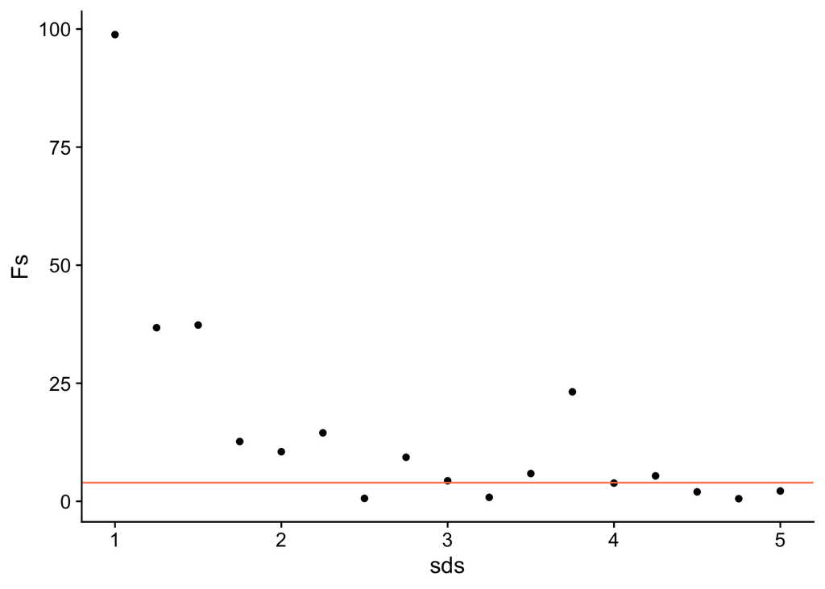

```r
# FIXME
# Step 4
fcrit <- qf(0.05, 1, 98, lower.tail = FALSE)

ggplot(sims, aes(x = sds, y = Fs)) +
  geom_point() +
  geom_hline(yintercept = fcrit, color = 'coral')
```

5. There is some noise because we are only performing the ANOVA for one data set for each standard deviation. Make a copy of your function (call it `getF2`) and add a loop inside the function to generate a data set and perform an ANOVA 100 times. Keep the F-value for each, and return the mean F-value. Then plot as above.

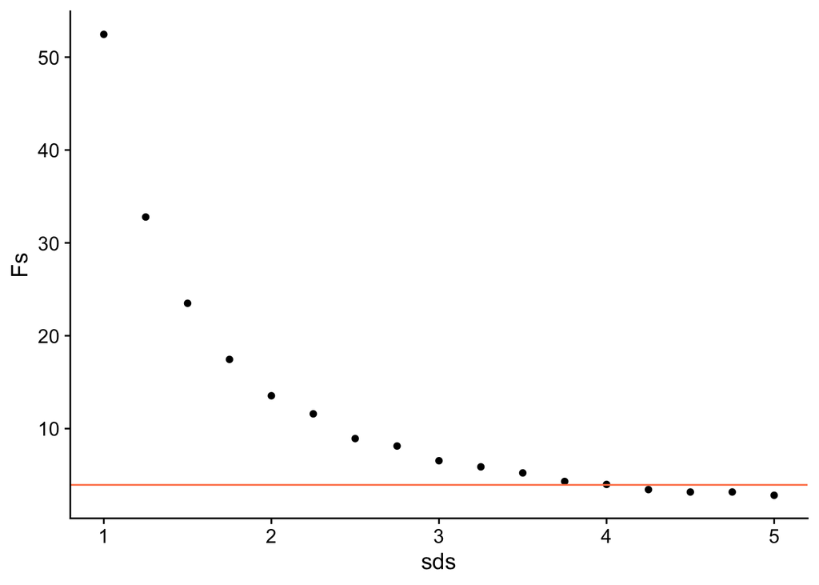

```r
# FIXME
# Step 5

getF2 <- function(mu1, mu2, sd_both, nobs) {
  niter <- 100
  Fs <- numeric(length = niter)
  for (ii in 1:niter) {
    x <- factor(rep(c(1, 2), each = nobs))
    y1 <- rnorm(nobs, mu1, sd_both)
    y2 <- rnorm(nobs, mu2, sd_both)
    y <- c(y1, y2)
    M <- data.frame(x, y)
    fm <- anova(lm(y ~ x, data = M))
    Fs[ii] <- fm$"F value"[1]
  }
  return(mean(Fs))
}

# Start over with a new copy of sims
sims <- data.frame(
  sd_both = sds,
  mu1 = rep(0, length = length(sds)),
  mu2 = rep(1, length = length(sds)),
  nobs = rep(100, length = length(sds))
)

sims <- sims |>
  mutate(Fs = pmap_dbl(sims, getF2))

fcrit <- qf(0.05, 1, 98, lower.tail = FALSE)

ggplot(sims, aes(x = sds, y = Fs)) +
  geom_point() +
  geom_hline(yintercept = fcrit, color = 'coral')
```

What do you observe in the plot?

> As the standard deviation increases, the $F$-statistic decreases.

Think of all the variables in this simulation. Which should be altered to change the within-group variance, and which to change the between-group variance?

> Within-group variance == standard deviation (what we have done here). Between-group variance == mean value for each group.

What do you think is the lower limit of $F$ (i.e., if you increased the standard deviation difference to a very large number)?

## Predicting height from limb lengths

```r
# FIXME
# Simulate data
set.seed(921)
N <- 100
height <- rnorm(N, 175, 2)
limb_prop <- runif(N, 0.4, 0.5)
left_limb <- limb_prop * height + rnorm(N, 0, 0.02)
right_limb <- limb_prop * height + rnorm(N, 0, 0.02)
M <- data.frame(height, left_limb, right_limb)
# write_csv(round(M, 1), "../data/Limb_Lengths.csv")
```

We should be able to predict someone’s height from the lengths of their limbs. The file `Limb_Lengths.csv` contains data for 100 heights and associated left and right limb lengths. We know that limb length is about 40-50% of total height, but we can develop a linear model for prediction.

### Activity

Load the data for limb lengths. Use `summarize_all()` to calculate the mean and standard deviation for each column. Look at the help to figure out how to apply two different functions to each column

```r
# FIXME
M <- read_csv("../data/Limb_Lengths.csv")
M |> head()
```

```
## # A tibble: 6 × 3
##   height left_limb right_limb
##    <dbl>     <dbl>      <dbl>
## 1   178       86.6       86.6
## 2   174.      80.1       80.1
## 3   176.      83.8       83.7
## 4   174.      81.5       81.5
## 5   177.      79.2       79.2
## 6   176       82.2       82.2
```

```r
M |> summarize_all(.funs = c("mean", "sd"))
```

```
## # A tibble: 1 × 6
##   height_mean left_limb_mean right_limb_mean height_sd left_limb_sd right_limb…¹
##         <dbl>          <dbl>           <dbl>     <dbl>        <dbl>        <dbl>
## 1        175.           78.7            78.7      1.82         5.31         5.31
## # … with abbreviated variable name ¹right_limb_sd
```

Make two plots, one for left limb length vs. height and one for right limb length vs. height. Use `plot_grid()` to put them side by side.

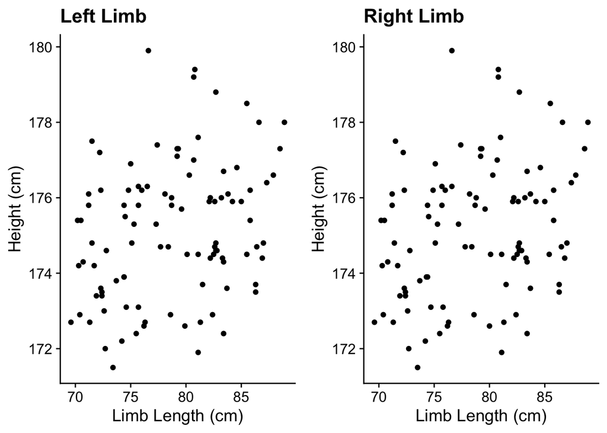

Fit a single linear model in which height is predicted by both left and right limb lengths (this is an “additive” model). Print out the summary of the model.

```r
# FIXME
fm_LR <- lm(height ~ left_limb + right_limb, data = M)
summary(fm_LR)
```

```
##
## Call:
## lm(formula = height ~ left_limb + right_limb, data = M)
##
## Residuals:
##     Min      1Q  Median      3Q     Max
## -3.4465 -1.1831  0.0258  1.1626  4.9766
##
## Coefficients:
##              Estimate Std. Error t value Pr(>|t|)
## (Intercept) 167.72060    2.64584  63.390   <2e-16 ***
## left_limb    -0.09373    3.66130  -0.026    0.980
## right_limb    0.18776    3.66341   0.051    0.959
## ---
## Signif. codes:  0 '***' 0.001 '**' 0.01 '*' 0.05 '.' 0.1 ' ' 1
##
## Residual standard error: 1.767 on 97 degrees of freedom
## Multiple R-squared:  0.07523,    Adjusted R-squared:  0.05617
## F-statistic: 3.946 on 2 and 97 DF,  p-value: 0.02252
```

Explain the results that you find. Why do you think that neither left nor right limb length is a good predictor of height in the model you fit?

```r
# FIXME
cor(M$left_limb, M$right_limb)
```

```
## [1] 0.9999583
```

> The correlation between them is > 0.99. When we fit a model that includes both limb lengths, there is severe multicollinearity. Separately each is probably a good predictor, but together, they are not good. All of the variation in Height is predicted by the 1st variable in the multiple regression, so there is no variation left for the 2nd variable to predict (and vice versa when the variables are reversed).

Fit separate linear models in which height is predicted by left and then right limb length.

```r
# FIXME
fm_L <- lm(height ~ left_limb, data = M)
summary(fm_L)
```

```
##
## Call:
## lm(formula = height ~ left_limb, data = M)
##
## Residuals:
##     Min      1Q  Median      3Q     Max
## -3.4477 -1.1810  0.0238  1.1665  4.9749
##
## Coefficients:
##              Estimate Std. Error t value Pr(>|t|)
## (Intercept) 167.73124    2.62423  63.916  < 2e-16 ***
## left_limb     0.09391    0.03327   2.823  0.00576 **
## ---
## Signif. codes:  0 '***' 0.001 '**' 0.01 '*' 0.05 '.' 0.1 ' ' 1
##
## Residual standard error: 1.758 on 98 degrees of freedom
## Multiple R-squared:  0.07521,    Adjusted R-squared:  0.06577
## F-statistic:  7.97 on 1 and 98 DF,  p-value: 0.005761
```

```r
fm_R <- lm(height ~ right_limb, data = M)
summary(fm_R)
```

```
##
## Call:
## lm(formula = height ~ right_limb, data = M)
##
## Residuals:
##     Min      1Q  Median      3Q     Max
## -3.4471 -1.1788  0.0248  1.1645  4.9758
##
## Coefficients:
##              Estimate Std. Error t value Pr(>|t|)
## (Intercept) 167.72530    2.62598  63.872  < 2e-16 ***
## right_limb    0.09398    0.03329   2.823  0.00575 **
## ---
## Signif. codes:  0 '***' 0.001 '**' 0.01 '*' 0.05 '.' 0.1 ' ' 1
##
## Residual standard error: 1.758 on 98 degrees of freedom
## Multiple R-squared:  0.07523,    Adjusted R-squared:  0.06579
## F-statistic: 7.972 on 1 and 98 DF,  p-value: 0.005755
```

Do these models make more sense?

> Yes, for each limb length is a significant predictor of height. This result is what we expect to see.

## Heart Transplant Survivorship

The data in `Heart_Transplants.xlsx` contains data on survivorship (in days; `Survival_Days`) for three groups of heart transplant patients. Patients were groups by the severity of the mismatch between donor and recipient (`Mismatch_Degree`): `Low`, `Medium`, and `High`. A low mismatch means a *good* match.

### Activity

Load the data from the Excel file and look at the structure with either `str()` or `glimpse()` (from tidyverse).

```r
# FIXME
M <- read_excel("../data/Heart_Transplants.xlsx")
str(M)
```

```
## tibble [39 × 2] (S3: tbl_df/tbl/data.frame)
##  $ Survival_Days  : num [1:39] 44 551 127 1 297 46 60 65 12 1350 ...
##  $ Mismatch_Degree: chr [1:39] "Low" "Low" "Low" "Low" ...
```

Notice that `Mismatch_Degree` is currently a character vector. To use it in a linear model, we need to convert it to a factor. We could do this with R’s built-in function `factor()`. The drawback is that, by default, `factor()` will order the factors in alphabetical order. For these data, the alphabetical order will put the `High` mismatch first, which is not ideal. We want to have `Low` come first.

[`forcats`](https://forcats.tidyverse.org/) is a package that greatly simplifies working with factors in R. It has functions to create factors in the order that they appear in the data.frame, in the order of frequency, and in any arbitrary order. `forcats` is built into the tidyverse, so you do not need to load it separately.

Because the data or organized so that the `Low` group is first, we can use `fct_inorder()` to make the factor in the sequence that we want.

Use `mutate()` and `fct_inorder()` to make `Mismatch_Degree` into a factor.

```r
# FIXME
M <- M |>
  mutate(Mismatch_Degree = fct_inorder(Mismatch_Degree))
```

There are only 39 observations total, so we may as well plot the raw data. Modify the code from the last two problem sets for plotting the points with the group means and standard errors.

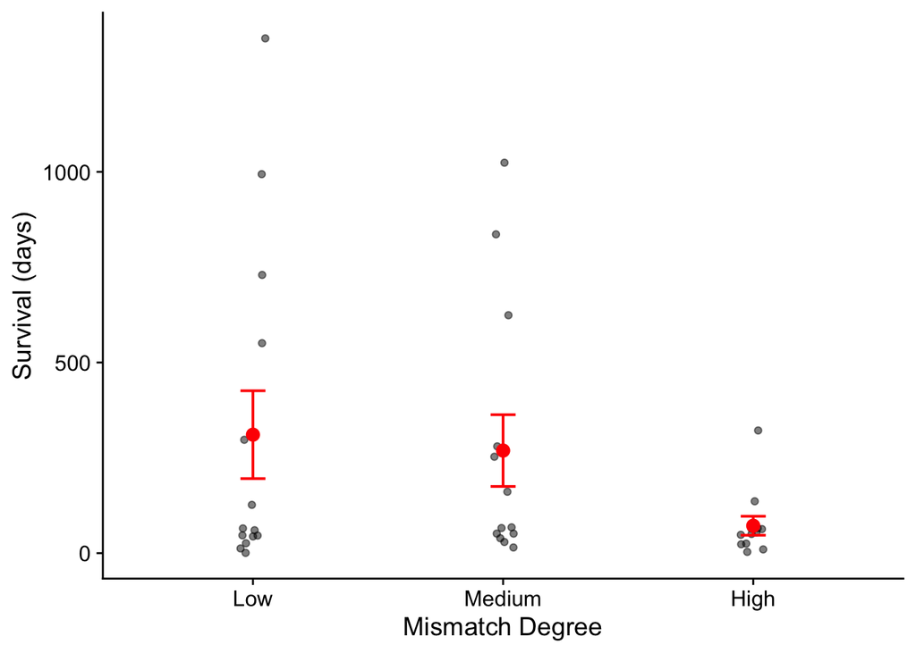

```r
#FIXME
ggplot(M, aes(x = Mismatch_Degree, y = Survival_Days)) +
  geom_point(position = position_jitter(width = 0.05, seed = 384729),
             alpha = 0.5) +
  stat_summary(fun = mean, geom = "point", size = 3, color = "red") +
  stat_summary(fun.data = mean_se, geom = "errorbar", width = 0.1,
               color = "red", linewidth = 0.7) +
  labs(x = "Mismatch Degree", y = "Survival (days)")
```

Describe what you see in the plots. You would like to be able to use a linear model (ANOVA) to compare the mean survival days between groups. In what way does the data not appear to satisfy the assumptions of ANOVA?

> The good and medium quality match groups are strongly right skewed. One of the assumptions of ANOVA is equal variance across the groups. We could explicitly thest this assuption, but there isn’t any reason to. The test will be significant for inequality. So we should just transform and go from there.

Find a transformation of `Survival_Days` that corrects the problems observed above. Plot your data each time with the transform. Briefly explain why you chose what you chose.

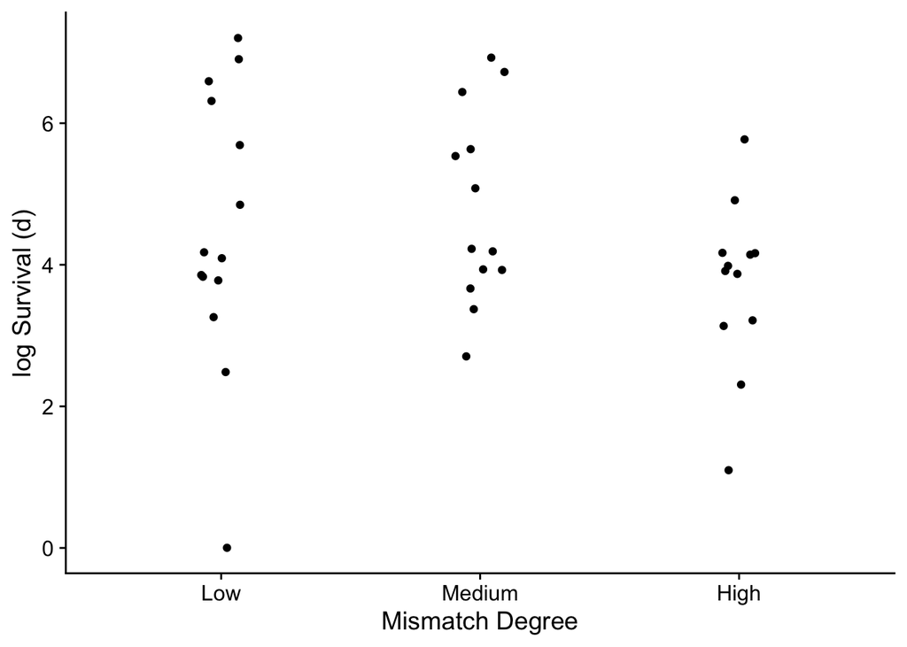

```r
# FIXME
M <- M |> mutate(log_Survival = log(Survival_Days))
ggplot(M, aes(x = Mismatch_Degree, y = log_Survival)) +
  geom_point(position = position_jitter(width = 0.1)) +
  xlab("Mismatch Degree") +
  ylab("log Survival (d)")
```

> To handle the right skew, we tried square-root first. It didn’t rein in the large values enough. log (here, natural), seems to do the trick. The variances look pretty similar.

Using `lm()`, fit a linear model in which transformed survival is modeled by the degree of mismatch. Save this to an object. Use `anova()` on that object to get the ANOVA table for the model you just fit.

```r
# FIXME
fm <- lm(log_Survival ~ Mismatch_Degree, data = M)
anova(fm)
```

```
## Analysis of Variance Table
##
## Response: log_Survival
##                 Df Sum Sq Mean Sq F value Pr(>F)
## Mismatch_Degree  2  7.611  3.8056  1.5598 0.2241
## Residuals       36 87.834  2.4398
```

```r
summary(fm)
```

```
##
## Call:
## lm(formula = log_Survival ~ Mismatch_Degree, data = M)
##
## Residuals:
##     Min      1Q  Median      3Q     Max
## -4.5019 -0.7913  0.1469  1.0132  2.7059
##
## Coefficients:
##                       Estimate Std. Error t value Pr(>|t|)
## (Intercept)             4.5019     0.4175  10.784 7.96e-13 ***
## Mismatch_DegreeMedium   0.2948     0.6016   0.490    0.627
## Mismatch_DegreeHigh    -0.7776     0.6145  -1.266    0.214
## ---
## Signif. codes:  0 '***' 0.001 '**' 0.01 '*' 0.05 '.' 0.1 ' ' 1
##
## Residual standard error: 1.562 on 36 degrees of freedom
## Multiple R-squared:  0.07974,    Adjusted R-squared:  0.02862
## F-statistic:  1.56 on 2 and 36 DF,  p-value: 0.2241
```

What do the results of this linear model show?

> Log-transformed survival (days) is not significantly different in the the three groups.

Fit another linear model just like the one above, but remove the intercept term by including `- 1` in the model: `lm(... ~ ... - 1)`. Compare the `summary()` of this model to the group means for each `Mismatch_Degree` (using `group_by()` and `summarize()`).

```r
# FIXME
fm2 <- lm(log_Survival ~ Mismatch_Degree - 1, data = M)
anova(fm2)
```

```
## Analysis of Variance Table
##
## Response: log_Survival
##                 Df Sum Sq Mean Sq F value    Pr(>F)
## Mismatch_Degree  3 749.30  249.77  102.37 < 2.2e-16 ***
## Residuals       36  87.83    2.44
## ---
## Signif. codes:  0 '***' 0.001 '**' 0.01 '*' 0.05 '.' 0.1 ' ' 1
```

```r
summary(fm2)
```

```
##
## Call:
## lm(formula = log_Survival ~ Mismatch_Degree - 1, data = M)
##
## Residuals:
##     Min      1Q  Median      3Q     Max
## -4.5019 -0.7913  0.1469  1.0132  2.7059
##
## Coefficients:
##                       Estimate Std. Error t value Pr(>|t|)
## Mismatch_DegreeLow      4.5019     0.4175  10.784 7.96e-13 ***
## Mismatch_DegreeMedium   4.7967     0.4332  11.072 3.82e-13 ***
## Mismatch_DegreeHigh     3.7243     0.4509   8.259 7.90e-10 ***
## ---
## Signif. codes:  0 '***' 0.001 '**' 0.01 '*' 0.05 '.' 0.1 ' ' 1
##
## Residual standard error: 1.562 on 36 degrees of freedom
## Multiple R-squared:  0.8951, Adjusted R-squared:  0.8863
## F-statistic: 102.4 on 3 and 36 DF,  p-value: < 2.2e-16
```

```r
M |> group_by(Mismatch_Degree) |>
  summarize(mean_survival = mean(log_Survival))
```

```
## # A tibble: 3 × 2
##   Mismatch_Degree mean_survival
##   <fct>                   <dbl>
## 1 Low                      4.50
## 2 Medium                   4.80
## 3 High                     3.72
```

What does removing the intercept term from an ANOVA linear model do?

> It forces R to estimate separate means for each group separately. This can be a useful technique.

## Bird abundance

The file `Birds.xlsx` contains data from Vuilleumier, F. (1970) Insular Biogeography in Continental Regions. I. The Northern Andes of South America. *American Naturalist* 104:373-388.

This paper explores the numbers of bird species in isolated “islands” of páramo vegetation in the Andes. The Missouri Botanical Garden can explain it better than we can (http://bit.ly/1PNWfsq):

> Within the tropical regions of Mexico, Central and South America, Africa, Malesia including New Guinea, and Hawaii, there is a vegetation type that occurs between the upper limit of continuous, closed-canopy forest (i.e., forest line or timberline) and the upper limit of plant life (i.e., snow line) that is characterized by tussock grasses, large rosette plants, shrubs with evergreen, coriaceous and sclerophyllous leaves, and cushion plants. This vegetation type is scattered along the crests of the highest mountain ranges or on isolated mountaintops between about 3000 meters (m) and 5000 m, like islands in a sea of forest.

We would like to use these data to see what the best predictor(s) of bird abundance is/are. The data contain species abundance (`N_Species`) and geographical information for 14 “islands”. Other data include:

1. `Area`: “Island” size (thousands of square km)
2. `Elevation`: Elevation (thousands of meters)
3. `Dist_to_Ecuador`: Distance to Ecuador (km)
4. `Dist_to_Island`: Distance to nearest island (km)

### Activity

We will use multiple regression to find the relative importance of each of these variables in predicting species abundance.

Start by loading the data and plotting histograms of the variables. You can make 5 different plots. Think about any variables that might need transformation. There are only 14 observations, so it’s going to be hard to discern normality. Here you are just looking for really obviously right or left skewed distributions.

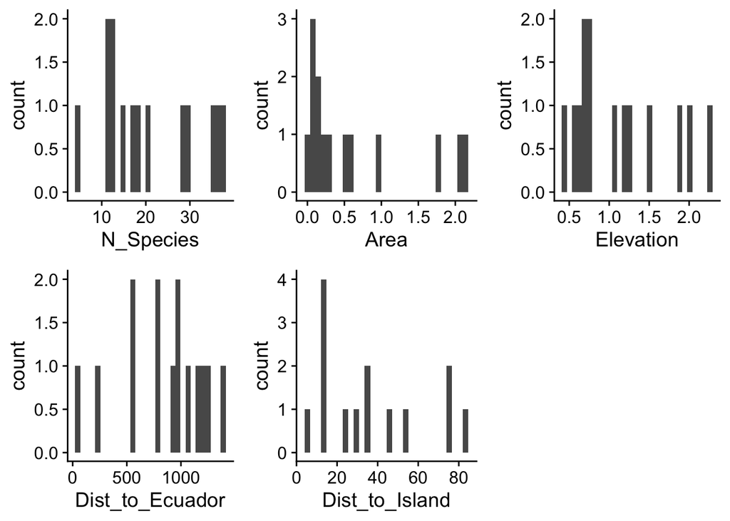

```r
# FIXME
M <- read_excel("../data/Birds.xlsx")
plot_grid(
  ggplot(M, aes(x = N_Species)) + geom_histogram(bins = 30),
  ggplot(M, aes(x = Area)) + geom_histogram(bins = 30),
  ggplot(M, aes(x = Elevation)) + geom_histogram(bins = 30),
  ggplot(M, aes(x = Dist_to_Ecuador)) + geom_histogram(bins = 30),
  ggplot(M, aes(x = Dist_to_Island)) + geom_histogram(bins = 30),
  ncol = 3)
```

Describe any patterns you see in the raw data.

> Area might be right skewed, but there really isn’t any way to tell for certain with so few observations. We could do some kind of normality test, but it would be terribly underpowered and thus not terribly informative. Square-root transforming area doesn’t appear to do much. Let’s just use the data as is, aware that we’ll have trouble drawing meaningful conclusions.

> We will tackle this same problem later in the course and explore ways to deal with the small sample size.

Insert a code chunk below and calculate the correlation table for the numeric variables.

```r
# FIXME
print(cor(M[, 2:6]), digits = 3)
```

```
##                 N_Species   Area Elevation Dist_to_Ecuador Dist_to_Island
## N_Species           1.000  0.583    0.4984          -0.695        -0.1351
## Area                0.583  1.000    0.6195          -0.159         0.1116
## Elevation           0.498  0.620    1.0000          -0.154         0.0218
## Dist_to_Ecuador    -0.695 -0.159   -0.1539           1.000         0.3542
## Dist_to_Island     -0.135  0.112    0.0218           0.354         1.0000
```

What patterns do you see in the correlations? Note that 1’s run along the diagonal (a variable correlated to itself is 1), and that the upper and lower triangles are symmetrical. Also note that you haven’t done any tests of significance, so you can’t say anything definitive about “significant correlations”.

> There are both positive and negative correlations. Some are moderately large ($\pm0.5-0.7$) and some are quite small (distance to the nearest island and elevation). Nothing really stands out good or bad.

Fit a linear model wherein species abundance is predicted by the other four variables. Save this model to an R object.

```r
# FIXME
fm <- lm(N_Species ~ Dist_to_Island + Elevation + Area + Dist_to_Ecuador,
         data = M)
```

Use `summary()` to get information about the model fit.

```r
# FIXME
summary(fm)
```

```
##
## Call:
## lm(formula = N_Species ~ Dist_to_Island + Elevation + Area +
##     Dist_to_Ecuador, data = M)
##
## Residuals:
##      Min       1Q   Median       3Q      Max
## -10.6660  -3.4090   0.0834   3.5592   8.2357
##
## Coefficients:
##                  Estimate Std. Error t value Pr(>|t|)
## (Intercept)     27.889386   6.181843   4.511  0.00146 **
## Dist_to_Island   0.016591   0.077573   0.214  0.83541
## Elevation        3.075136   4.000326   0.769  0.46175
## Area             5.153864   3.098074   1.664  0.13056
## Dist_to_Ecuador -0.017216   0.005243  -3.284  0.00947 **
## ---
## Signif. codes:  0 '***' 0.001 '**' 0.01 '*' 0.05 '.' 0.1 ' ' 1
##
## Residual standard error: 6.705 on 9 degrees of freedom
## Multiple R-squared:  0.7301, Adjusted R-squared:  0.6101
## F-statistic: 6.085 on 4 and 9 DF,  p-value: 0.01182
```

R<sup>2</sup> is a measure of how much of the variation in the outcome variable (`N_Species`) is explained by the predictors. R<sup>2</sup> for linear models in R is “Multiple R-squared” (ignore “Adjusted R-squared”) in the summary.

What is the R<sup>2</sup> for the regression model?

> *R*<sup>2</sup> = 0.73

Overall, are the four variables able to predict species abundance in combination (overall ANOVA)?

What variable or variables are significantly different from 0? Does species abundance increase or decrease with a one unit increase in this/these variable(s)?

> The only significant predictor is distance to Ecuador: *P* = 0.01. As distance to Ecuador increases, species abundance decreases. For each 1 km farther from Ecuador, species abundance drops by 0.02 species.
[^1]: It’s not just a clever name.